# Aplicação PNL

Victor Antonio | Felipe Giacomini | Riquelme Pereira

11-09-2024

# Aplicação

Vamos fazer uma aplicação em R detalhada de Processamento de Linguagem Natural (PLN).

## Objetivo

O objetivo desta aplicação é coletar avaliações de um produto (no exemplo, um Iphone 15) em um site de e-commerce e realizar uma análise de sentimentos sobre as opiniões dos usuários.

## Importação das Bibliotecas

```r
library("tidyr") # transformar e organizar dados
library("tidytext") # Pré-processamento de texto
library("stringr") # Manipulação de strings
library("rvest") # Coletar dados de sites
library("dplyr") # Manipulação de dados (filtros, contagens e agrupamentos)
library("ggplot2") # Visualizações gráficas
library("wordcloud") # Criar nuvens de palavras com as palavras mais frequentes
library("reshape2") # Reestruturar dados para análise ou visualização
library("RColorBrewer") # Paletas de cores para gráficos e visualizações
library("tm") # Pré-processamento stopwords
library("ptstem") # Stemming de palavras em português
library("lexiconPT") # Léxicos em português para análise de sentimentos
library("igraph") # Visualização de redes e grafos
library("ggraph") # Complemento ao igraph
```

## Coletando Avaliações do Produto Usando *rvest*

Aqui, vamos usar o *rvest* para coletar as avaliações do site de e-commerce da Amazon para o Iphone-15.

```r
# Função para coletar avaliações de uma página específica
pega_avaliacoes <- function(page_number) {
  url <- paste0("https://www.amazon.com.br/Apple-iPhone-15-128-GB/",
                "product-reviews/B0CP6CVJSG/ref=cm_cr_getr_d_paging_btm_prev_1?",
                "ie=UTF8&reviewerType=all_reviews&pageNumber=", page_number)

  webpagina <- read_html(url)

  # Extraindo as avaliações
  avaliacoes <- webpagina %>%
    html_nodes(".review-text") %>%
    html_text()

  return(avaliacoes)
}

# número de paginas a ser coletadas
numero_paginas <- 10

# Coletar as avaliações de todas as páginas
todas_avaliacoes <- lapply(1:numero_paginas, pega_avaliacoes)

# Unir todas as listas de avaliações
todas_avaliacoes <- unlist(todas_avaliacoes)

# Visualizar as primeiras avaliações
head(todas_avaliacoes,2)
```

```
## [1] "\n\n\n\n\n\n\n\n  \n  \n    Smartphone rápido,  com qualidade excelente nas fotos (mas precisa acertar as configurações antes), bateria que dura dois dias dependendo do uso, super leve e bonitinho. Confuso de mexer para quem está acostumado com Android. Não possui Touch ID somente Face ID.\n…
## [2] "\n\n\n\n\n\n\n\n  \n  \n    A respeito do produto, sem nenhuma surpresa! Celular top de linhas, acabamento está ótimo, as bordas estão mais arredondadas em comparação com o 13, não temos titânio nesse modelo (somente na linha Pro) mas o vidro fosco compensa, acabando com os problemas de marc…
```

Após a coleta dos nossos dados textuais vamos aplicar e mostrar a importância do Pré processamento de texto.

## Pré-processamento das Avaliações

### Convertendo para o formato *tidy*

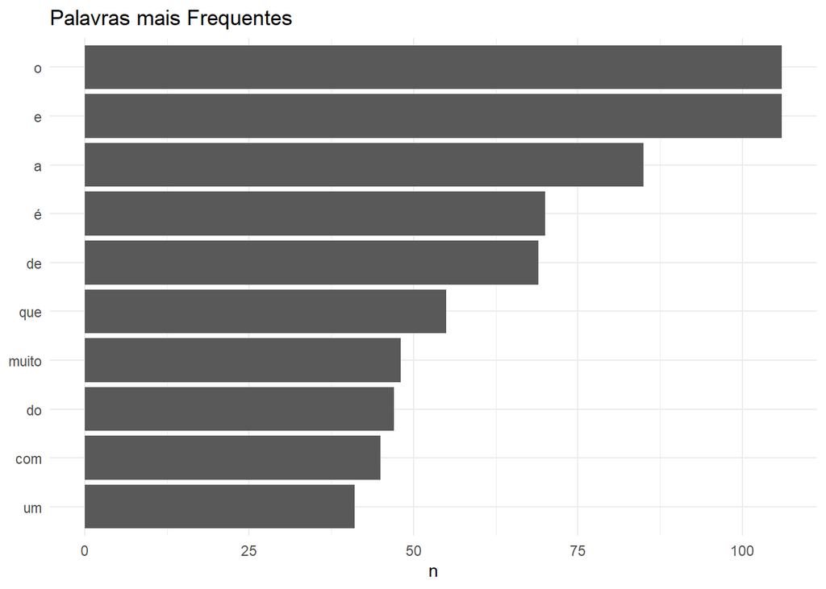

```r
# Convertendo as avaliações para um formato tidy
avaliacoes_df <- data.frame(texto = todas_avaliacoes)

# Tokenizando
tidy_avaliacoes <- avaliacoes_df %>%
  unnest_tokens(palavra, texto)

# Visualizando as palavras mais frequentes

tidy_avaliacoes %>%
  count(palavra, sort = TRUE) %>% # Para ordenar a lista por frequência
  mutate(palavra = reorder(palavra, n)) %>% # Manter a ordenação de frequência
  top_n(10) %>%
  ggplot(aes(palavra, n)) +
  geom_col() +
  xlab(NULL) +
  coord_flip() +
  ggtitle("Palavras mais Frequentes") +
  theme_minimal()
```

Como podemos perceber, temos muitas stopwords e acentuações que estão atrapalhando a nossa análise, por isso a importância do Pré-Processamento.

Para isso, vamos aplicar primeiramente a Stemmização usando a biblioteca *ptstem.*

### Stemmização

```r
tidy_avaliacoes$palavra <- ptstem(tidy_avaliacoes$palavra)
```

Após, vamos remover os acentos das palavras.

### Removendo Acentos

```r
# Sequência de caracteres sem acentos
p = c("a","e","i","o","u","a","e","i","o","u","a","e","i","o","u","a","o","c")
# Sequência de caracteres com acentos
names(p) = c("á","é","í","ó","ú","à","è","ì","ò","ù","â","ê","î","ô","û","ã",
             "õ","ç")

# removendo acentos
tidy_avaliacoes <- tidy_avaliacoes %>%
  mutate(palavra = str_replace_all(palavra, p))
```

Por fim, vamos remover as palavras pouco relevantes com o pacote *tm*.

### Removendo stopwords

```r
tidy_avaliacoes <- tidy_avaliacoes %>%
  filter(!palavra %in% stopwords(kind = "pt"))
```

Após todo o Pré-Processamento das palavras vamos visualizar como está a visualização.

### Visualização pós Pré-Processamento

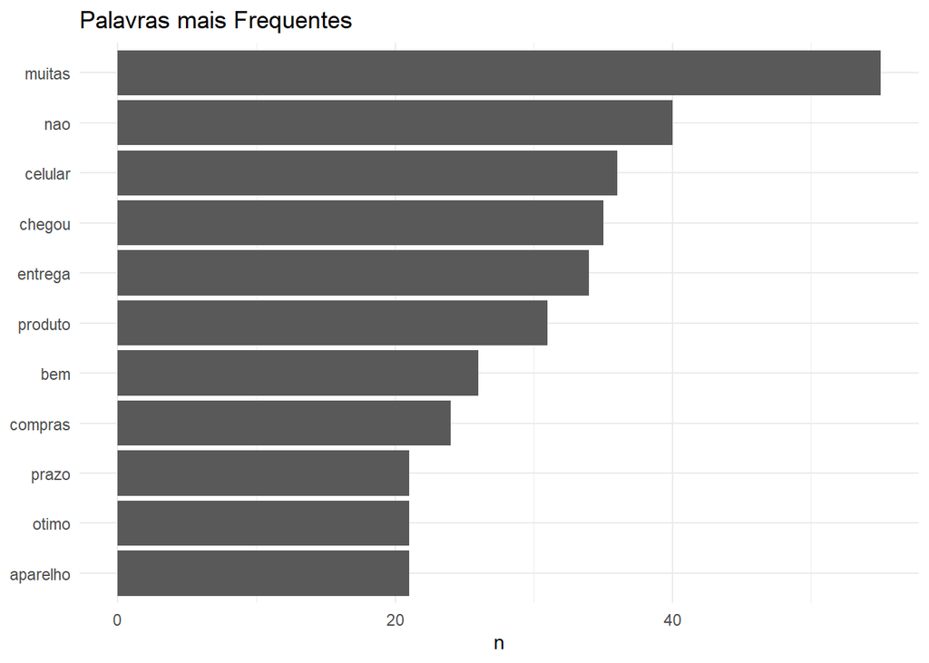

```r
# Visualizando as palavras mais frequentes

tidy_avaliacoes %>%
  count(palavra, sort = TRUE) %>% # Para ordenar a lista por frequência
  mutate(palavra = reorder(palavra, n)) %>% # Manter a ordenação de frequência
  top_n(10) %>%
  ggplot(aes(palavra, n)) +
  geom_col() +
  xlab(NULL) +
  coord_flip() +
  ggtitle("Palavras mais Frequentes") +
  theme_minimal()
```

## Análise Descritiva das Avaliações

Vamos agora realizar uma análise descritiva a fim de entender o comportamento dos nossos dados. Primeiramente vamos gerar uma nuvem de palavras.

### Word Clouds

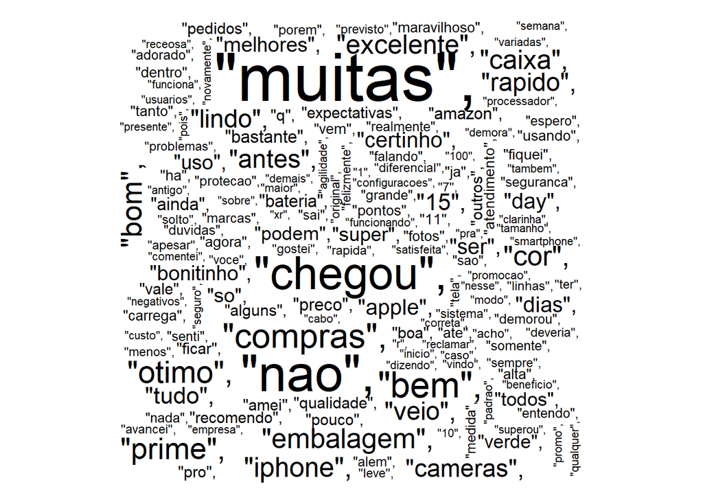

```r
tidy_avaliacoes %>%
  wordcloud()
```

### Análise de sentimentos

Usando o léxico *oplexicon_v3.0* do pacote *lexiconPT* podemos adicionar polaridades positivas, negativas ou neutras as palavras presentes nas avaliações.

```r
sentimento <- oplexicon_v3.0 %>% select(term, polarity) %>%
  rename(palavra=term)

tidy_avaliacoes_palavras <- distinct(tidy_avaliacoes) %>%
  left_join(sentimento, by="palavra")

tidy_avaliacoes_palavras %>%
  summarize(sentimento=mean(polarity, na.rm=T))
```

```
##   sentimento
## 1  0.1708861
```

Uma polaridade média de 0.17 indica que as avaliações no geral são positivas.

## N-Grams

Podemos não só trabalhar com palavras únicas, mas dividir o texto em várias formas. Por exemplo, podemos identificar pares de palavras - cada vez que um par de palavras - ‘iphone 15’ - aparecem juntos. Isso se chama um ‘bigram’. A lógica de processamento é bem parecida com a rotina para palavras únicas.

### Tokenizando em Bi-grams

```r
tidy_avaliacoes_bigram <- avaliacoes_df %>% unnest_tokens(bigram, texto,
                                       token="ngrams", n=2)
head(tidy_avaliacoes_bigram)
```

```
##                bigram
## 1   smartphone rápido
## 2          rápido com
## 3       com qualidade
## 4 qualidade excelente
## 5       excelente nas
## 6           nas fotos
```

### Pré-processamento dos Bi-gram

O pré processamento é muito parecido com o caso de unigram(palavra), o que fica um pouco mais complexo é a questão das stopwords.

```r
tidy_avaliacoes_bigram <- tidy_avaliacoes_bigram %>%
  separate(bigram, c("palavra1","palavra2"), sep = " ") %>% # Separando as words
  mutate(palavra1 = ptstem(palavra1),
         palavra2 = ptstem(palavra2)) %>% # Stemizando
  mutate(palavra1 = str_replace_all(palavra1, p),
         palavra2 = str_replace_all(palavra2, p)) %>% # Removendo Acentos
  filter(!palavra1 %in% stopwords(kind = "pt")) %>% # Removendo stopwords
  filter(!palavra2 %in% stopwords(kind = "pt")) %>% # Removendo stopwords
  mutate(bigram = paste(palavra1,palavra2,sep = " ")) %>%
  select(bigram)

head(tidy_avaliacoes_bigram)
```

```
##                bigram
## 1   smartphone rapido
## 2 qualidade excelente
## 3     precisa acertar
## 4 configuracoes antes
## 5       antes bateria
## 6           dura dois
```

Podemos perceber que após a remoção das stopwords, *bi-grams* como “rápido com” e “excelente nas” sumiram, o que faz sentido, porém “com qualidade” também sumiu, um *bi-gram* que apesar de possuir uma stopword(“com”) talvez faria sentido na análise.

### Análise Descritiva dos Bi-Grams

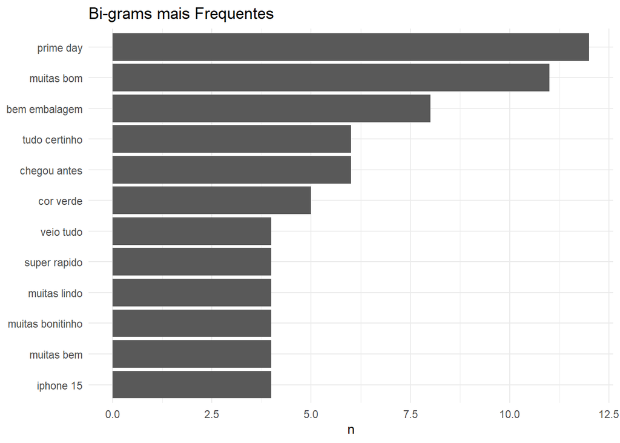

```r
# Visualizando as palavras mais frequentes

tidy_avaliacoes_bigram %>%
  count(bigram, sort = TRUE) %>% # Para ordenar a lista por frequência
  mutate(bigram = reorder(bigram, n)) %>% # Manter a ordenação de frequência
  top_n(10) %>%
  ggplot(aes(bigram, n)) +
  geom_col() +
  xlab(NULL) +
  coord_flip() +
  ggtitle("Bi-grams mais Frequentes") +
  theme_minimal()
```

Podemos perceber nos *bi-grams* mais frequentes, como “prime day” e relacionados a entrega como “super rapido” mostrando uma qualidade do e-commerce analisado, bem como “muitas bom”, “muitas bem”, “muitas bonitinho” relacionados positivamente ao produto analisado.

### Rede de Bigramas

O método anterior é interessante para visualizar os bigramas mais frequentes, mas seria interessante poder ter uma visão mais ampla destas relações entre palavras. A seguir, vemos como podemos ter essa visão geral usando uma rede de palavras com os pacotes *igraph* e *ggraph.*

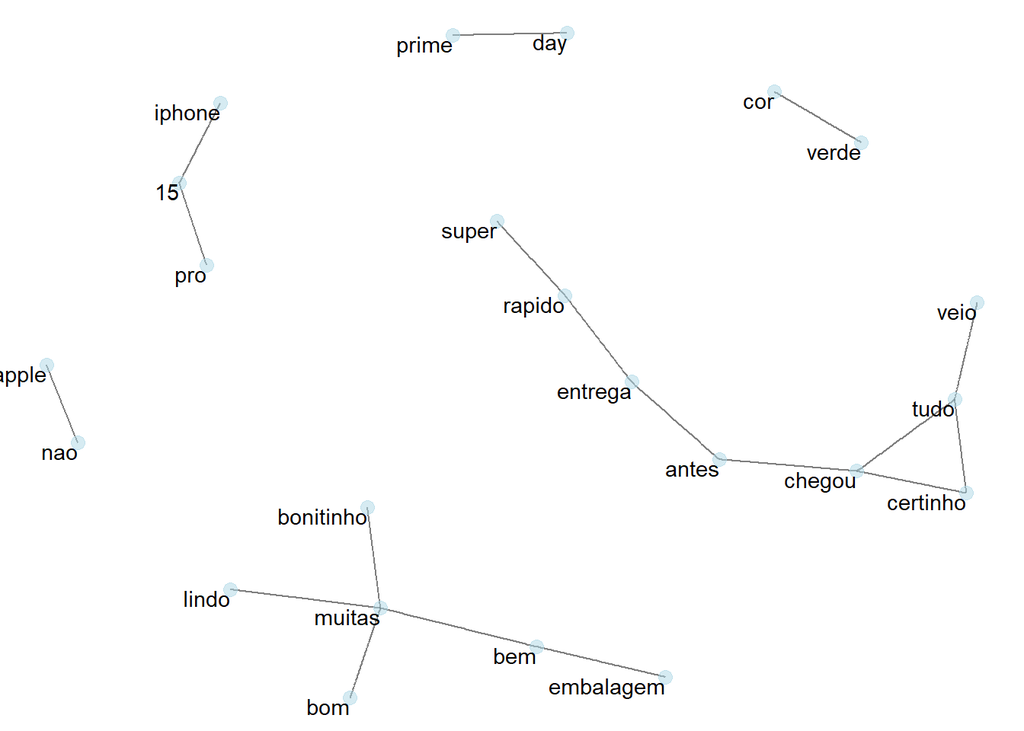

```r
tidy_avaliacoes_bigram  %>%
  separate(bigram,c("palavra1","palavra2"),sep = " ") %>%
  count(palavra1,palavra2,sort = T) %>%
  filter(n > 2) %>% # Filtrando bigramas que aparecem mais do que 2 vezes, pelo menos.
  graph_from_data_frame() %>% # Gera as relações direcionais entre palavras.
  ggraph(layout = "fr") +
  geom_edge_link(alpha = 0.5) + # Alpha para adicionar transparência as retas.
  geom_node_point(color = "lightblue",
                  size = 3, alpha = 0.5) + # Definindo cor e tamanho dos pontos.
  geom_node_text(aes(label = name),
                 vjust = 1, hjust = 1) + # vjust, hjust para deslocar os textos.
  theme_void() # Remover eixos e cor do fundo.
```

A rede de bigramas gerada nos permite visualizar as palavras que frequentemente aparecem juntas nas avaliações do iPhone 15, fornecendo uma visão mais ampla das conexões entre os termos. É possível observar padrões de satisfação relacionados à entrega (“chegou”, “certinho”, “entrega”), além de termos de elogio como “lindo”, “bonitinho”, “embalagem” que sugerem comentários sobre a aparência e a apresentação do produto.